# ctsGE Package

Michal Sharabi-Schwager, Ron Ophir

2017-01-07

#### Abstract

A prerequisite to clustering noisy data, such as gene-expression data, is the filtering step. ctsGE is an R package that performs clustering of time-series gene-expression data: as an alternative to the filtering step, it applies a sorting step in which all of the data are divided into small groups according to how the time points are related to the time-series median. Then, clustering is performed separately on each group, using a “structure-based” dissimilarity concept(e.g., Lin and Li[^1]; Corduas[^2]). Thus, the clustering is done in two steps. First an expression index (i.e., a sequence of 1,-1, and 0) is defined that divides genes into groups according to their expression profiles, and then genes with the same index are clustered by applying **K-means**. The **ctsGE** package also provides an interactive tool to visualize and explore the gene-expression patterns and their subclusters.

# 1 Installing ctsGE

```r
source("https://bioconductor.org/biocLite.R")
biocLite("ctsGE")
#loading the package
library(ctsGE)
```

# 2 Workflow of clustering with ctsGE

1. Build the expression matrix from expression data
2. Define an expression index (i.e., a sequence of 1,-1, and 0) for each gene
3. Cluster the gene set with the same index, applying **K-means**:
   $$kmeans(genesInIndex,k)$$
4. Graphic visualization of expression patterns
5. Interactive visualization and exploration of gene-expression data

# 3 Building the expression matrix

## 3.1 Loading data from GEO

Load the files and make a list of the `matrix`:

When reading the normalized expression values the function check whether there are rows that their median absolute deviation (MAD) value equal to zero and remove these rows. This step is important in order to continue to the next step of indexing the data.

```r
library(GEOquery)

gse2077 <- getGEO('GSE2077')
gseAssays <- Biobase::assayData(gse2077)
gseExprs <- Biobase::assayDataElement(gseAssays[[1]][,c(1:6)],'exprs')

# list of the time series tables use only 6 samples
gseList <- lapply(1:6,function(x){data.frame(Genes = rownames(gseExprs),Value = gseExprs[,x])})
names(gseList) <- colnames(gseExprs)
```

Build the expression matrix from the list of matrices:

```r
rts <- readTSGE(gseList,labels = c("0h","6h","12h","24h","48h","72h"))
```

## 3.2 Loading data from files

Here is an example of how to load the time-series files from your directory; data is loaded from the ‘extdata’ directory of the **ctsGE** package:

```r
data_dir <- system.file("extdata", package = "ctsGE")
files <- dir(path=data_dir,pattern = "\\.xls$")
```

**Building from a directory:**

```r
rts <- readTSGE(files, path = data_dir, labels = c("0h","6h","12h","24h","48h","72h") )
```

**ctsGE Object summary:**

```r
names(rts)
```

```
## [1] "tsTable"    "samples"    "tags"       "timePoints"
```

```r
rts$timePoints
```

```
## [1] 6
```

```r
head(rts$samples)
```

```
## [1] "0h"  "6h"  "12h" "24h" "48h" "72h"
```

```r
head(rts$tags)
```

```
## [1] "1000_at"   "1001_at"   "1002_f_at" "1003_s_at" "1004_at"   "1005_at"
```

`head(rts$tsTable)`

|  | 0h | 6h | 12h | 24h | 48h | 72h |
| --- | --- | --- | --- | --- | --- | --- |
| **1000_at** | 3741 | 3134 | 2724 | 2182 | 2730 | 3379 |
| **1001_at** | 53.3 | 44.1 | 43.8 | 113.9 | 43.9 | 68.5 |
| **1002_f_at** | 158.7 | 130.8 | 110.5 | 39.4 | 48.7 | 126 |
| **1003_s_at** | 517 | 81.6 | 168.6 | 352.5 | 186 | 127.5 |
| **1004_at** | 346.5 | 338.3 | 399.5 | 391.2 | 502.6 | 366 |
| **1005_at** | 85 | 439.9 | 941.7 | 449.6 | 616 | 553.2 |

### 3.2.1 Adding genes annotation to time series table

The `desc` argument in the function **readTSGE** is used in order to add genes annotation to the time series table.

# 4 Defining the expression index

1. First, the expression matrix is standardized. The function default standardization method is a median-based scaling; alternatively, a mean-based scaling can be used. The new standardized values represent the distance of each gene at a certain time point from its center, median or mean, in median absolute deviation (MAD) units or standard deviation (SD) units, respectively.
2. Next, the standardized values are converted to index values that indicate whether gene expression is above, below or within the limits around the center of the time series, i.e., **1 / -1 / 0**, respectively. The function defines a parameter cutoff (see Section 4.1) that determines the limits around the gene-expression center.Then the function calculates the index value at each time point according to:
   - **0:** standardized value is within the limits (+/- cutoff)
   - **1:** standardized value exceeds the upper limit (+ cutoff)
   - **-1:** standardized value exceeds the lower limit (- cutoff)
3. The `+/- cutoff` parameter defines a reference range to which the data are compared. When the range is too big, more time-series points will fall into it and will get an index value of 0, and this may be misleading. A narrow range increases the variety of index groups as a result of high sensitivity to small fluctuations in the time-series profile. The default cutoff values range from 0.5 to 0.7 in increments of 0.05 are used to choose the optimal cutoff  
   (see Section 4.1).

## 4.1 Checking the optimal cutoff

The function `PreparingTheIndexes` generates an expression index (i.e., a sequence of 1,-1, and 0) that represents the expression pattern along time points for each gene. Setting different limits for the center era (with the `cutoff` parameter) will change the index for each gene-expression profile and consequently, the number of genes in each index group. Following the idea that instead of filtering “irrelevant” genes to reduce the noise, the clustering will be performed on small gene groups, one would like to choose a cutoff value, that will minimize the number of genes in each group, i.e., generate index groups of equal size. The test for equality is performed by calculating the chi-squared value from a comparison between the number of genes in the index groups and the null hypothesis that all index groups are equal. The test is performed for a set of cutoffs within a given range.The cutoff that gives the minimal chi-squared value is the most likely to generate equal index groups. The range of the cutoff values is given by `min_cutoff` and `max_cutoff` arguments. However, by assigning the same value to min and max parameters one can define a cutoff regardless of what was suggested by the function.

```r
prts <- PreparingTheIndexes(x = rts, min_cutoff=0.5, max_cutoff=0.7, mad.scale = TRUE)
```

**`cutoff = 0.55` is the optimal cutoff with the lowest chi-squared value**

```r
prts$cutoff
```

```
## [1] 0.55
```

### 4.1.1 Index properties

To explore how informative the expression profiles are, we counted the number of zeros in each index. In this tutorial example, the index can have no zeros, one zero or up to six zeros; overall, the indexes and genes are divided into seven groups. Indexes for which most of the time points present a zero value (in this example, three or more time points) are expected to show a pattern in which gene-expression does not change much along the time points. Indexes with less zeros to no zeros (two or less in the example) will show genes with up- or downregulated expression at each time point.

```
With cutoff =
0.55, most of the genes were assigned to indexes with three or two zeros,
indicating a variety of expression patterns.
```

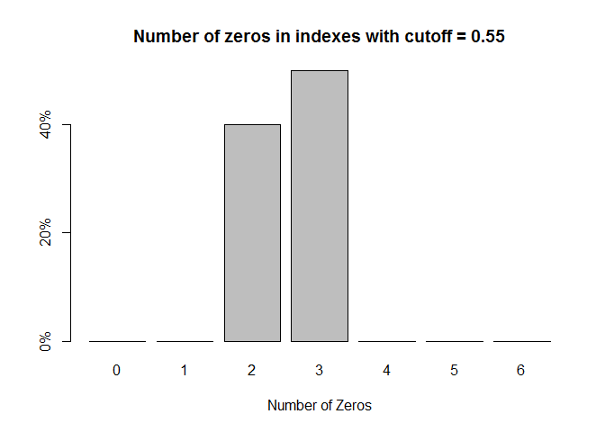

## 4.2 Preparing the indexes

A **`cutoff = 0.55`** was chosen

```r
prts <- PreparingTheIndexes(x = rts, mad.scale = TRUE)
names(prts)
```

```
## [1] "tsTable"    "samples"    "tags"       "timePoints" "scaled"
## [6] "index"      "cutoff"
```

**Gene expression after standardization:** `head(prts$scaled)`

|  | 0h | 6h | 12h | 24h | 48h | 72h |
| --- | --- | --- | --- | --- | --- | --- |
| **1000_at** | 1.665 | 0.4156 | -0.4283 | -1.544 | -0.4156 | 0.9207 |
| **1001_at** | 0.6397 | -0.6397 | -0.6814 | 9.067 | -0.6675 | 2.754 |
| **1002_f_at** | 1.03 | 0.3194 | -0.1973 | -2.007 | -1.77 | 0.1973 |
| **1003_s_at** | 3.149 | -0.8873 | -0.08066 | 1.624 | 0.08066 | -0.4617 |
| **1004_at** | -0.817 | -1.026 | 0.532 | 0.3207 | 3.156 | -0.3207 |
| **1005_at** | -3.19 | -0.4711 | 3.373 | -0.3968 | 0.8779 | 0.3968 |

**Gene expression indexing with `cutoff = 0.55`:** `head(prts$index)`

|  | 0h | 6h | 12h | 24h | 48h | 72h | index |
| --- | --- | --- | --- | --- | --- | --- | --- |
| **1000_at** | 1 | 0 | 0 | -1 | 0 | 1 | 100-101 |
| **1001_at** | 1 | -1 | -1 | 1 | -1 | 1 | 1-1-11-11 |
| **1002_f_at** | 1 | 0 | 0 | -1 | -1 | 0 | 100-1-10 |
| **1003_s_at** | 1 | -1 | 0 | 1 | 0 | 0 | 1-10100 |
| **1004_at** | -1 | -1 | 0 | 0 | 1 | 0 | -1-10010 |
| **1005_at** | -1 | 0 | 1 | 0 | 1 | 0 | -101010 |

## 4.3 Clustering each index with K-means

The clustering is done with K-means. To choose an optimal k for K-means clustering, the Elbow method was applied[^4]. This method looks at the percentage of variance explained as a function of the number of clusters: the chosen number of clusters should be such that adding another cluster does not give much better modeling of the data. First, the ratio of the within-cluster sum of squares (WSS) to the total sum of squares (TSS) is computed for different values of k (i.e., 1, 2, 3 …). The WSS, also known as sum of squared error (SSE), decreases as k gets larger. The Elbow method chooses the k at which the SSE decreases abruptly. This happens when the computed value of the WSS-to-TSS ratio first drops from 0.2.

$\frac{WSS}{TSS} < 0.2$

```r
ClustIndexes <- ClustIndexes(prts, scaling = TRUE)
names(ClustIndexes)
# table of the index and the recommended k that were found by the function
head(ClustIndexes$optimalK)

# Table of clusters index for each gene
head(ClustIndexes$ClusteredIdxTable)
```

Running `kmeans` and calculating the optimal k for each one of the indexes in the data could take a long time. To shorten the procedure the user can skip this step and directly view a specific index and its clusters by running either the `PlotIndexesClust()` or the `ctsGEShinyApp()` function

# 5 Graphic visualization of an index

The `PlotIndexesClust()` function generates graphs and tables of a specific index and its clusters. The user decides whether to supply the k or let the function calculate the k for the selected index.

```r
indexPlot <- PlotIndexesClust(prts,idx = "1100-1-1",scaling = TRUE)
names(indexPlot)
```

```
## [1] "Clust_4_1100-1-1" "graphs"
```

**Genes in ‘1100-1-1’ index and their clusters** **(k was chosen by the function):**  
Number of clusters (k) for ‘1100-1-1’ is: **`length(indexPlot$graphs)`**

```
## [1] 4
```

**Table of genes in ‘1100-1-1’ index, seperated to clusters:** `head(indexPlot[[1]])`

Table continues below

|  | 0h | 6h | 12h | 24h | 48h |
| --- | --- | --- | --- | --- | --- |
| **1048_at** | 0.6255 | 0.9085 | 0.1815 | -0.1815 | -1.143 |
| **104_at** | 0.8152 | 0.7462 | -0.09904 | 0.09904 | -1.028 |
| **1870_at** | 0.7476 | 0.6014 | 0.1628 | -0.1628 | -2.814 |
| **1872_at** | 0.5597 | 1.259 | 0.3135 | -0.3135 | -2.256 |
| **31423_at** | 0.954 | 0.6654 | 0.1701 | -0.1701 | -0.7231 |
| **31474_r_at** | 0.7112 | 1.276 | -0.3497 | 0.3497 | -0.6378 |

|  | 72h | clusters |
| --- | --- | --- |
| **1048_at** | -0.7235 | 4 |
| **104_at** | -0.6028 | 4 |
| **1870_at** | -2.136 | 4 |
| **1872_at** | -0.7892 | 4 |
| **31423_at** | -0.6836 | 4 |
| **31474_r_at** | -1.523 | 4 |

This example focus on `1100-1-1` index. This index indicates expression profile that is upregulated at the beginning and gradually downregulated along the time points. Since the index only states whether gene expression is upregulated (1), downregulated (-1) or stays the same (0)rather than the exact expression level, many expression profiles may fall under such index. The following K-means step helps to split the profiles under that index group into more coherent clusters.

**Line graphs of the genes’ expression patterns in index ‘1100-1-1’ separated** **into clusters:**

```
## $`Clust_1_1100-1-1`
```

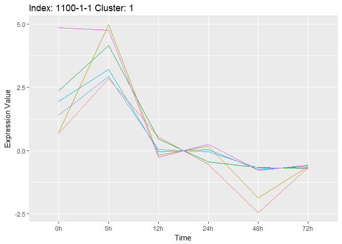

```
##
## $`Clust_2_1100-1-1`
```

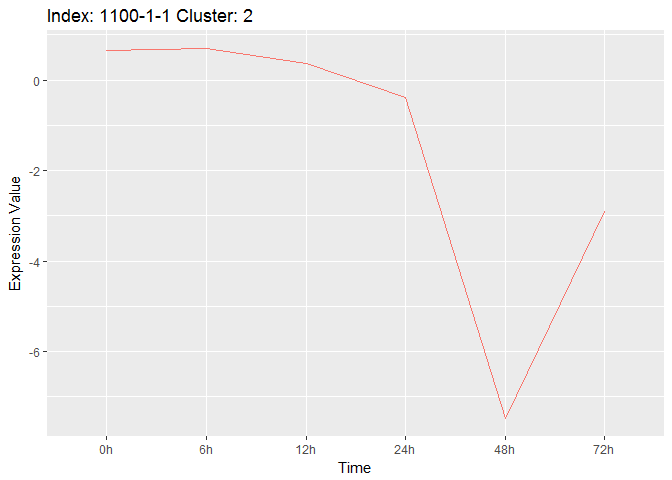

```
##
## $`Clust_3_1100-1-1`
```

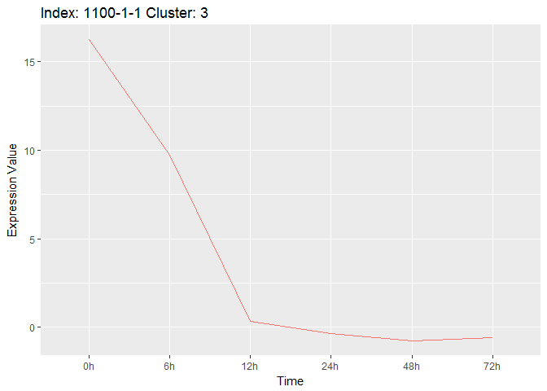

```
##
## $`Clust_4_1100-1-1`
```

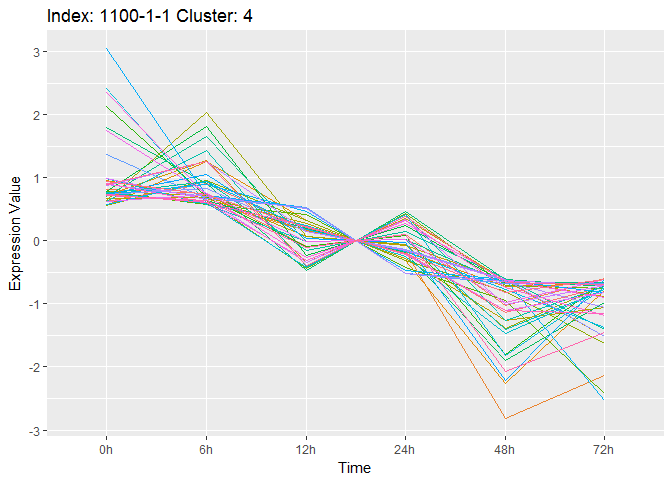

```r
indexPlot$graphs
```

## 5.1 Export gene expression table to file

Genes expression data in index ‘1100-1-1’ separated into cluster can be exported with R function `write.table`:

```
write.table(indexPlot[[1]], file, sep = "\t")
```

# 6 GUI for interactive exploration of gene-expression data

The `ctsGEShinyApp` function the ctsGE object,and opens an html page as a GUI. On the web page, the user chooses the profile to visualize and the number of clusters (k parameter for K-means) to show. The line graphs of the profile separated into clusters will show in the main panel, and a list of the genes and their expressions will also be available. The tables and figures can be downloaded.

*Note that running the Shiny GUI block the current session while running.

## 6.1 Screenshots of the GUI

```r
library(shiny)
library(DT)
ctsGEShinyApp(rts)
```

### 6.1.1 [The graph tab](http://vitisexonusage.byethost9.com/ctsGEShinyApp_tab1.png)

### 6.1.2 [The table tab](http://vitisexonusage.byethost9.com/ctsGEShinyApp_tab2.png)

[^1]: Lin J, Li Y (2009). Finding Structural Similarity in Time Series Data Using Bag-of-Patterns Representation. In Proceedings of the 21st International Conference on Scientific and Statistical Database Management (SSDBM 2009), Marianne Winslett (Ed.). Springer-Verlag, Berlin, Heidelberg, pp. 461–477. ISBN 978-3-642-02278-4.
[^2]: Corduas M (2010). Mining Time Series Data: A Selective Survey. In Proceedings of the 6th Conference of the Classification and Data Analysis Group of the SocietàItaliana di Statistica, F Palumbo, CN Lauro,MJ Greenacre (Eds.). Springer-Verlag, Berlin, Heidelberg, pp. 355–362. ISBN 978-3-642-03739-9.
[^3]: Deng M, Lancto CA, Abrahamsen MS (2004). Cryptosporidium parvum regulation of human epithelial cell gene expression. Int. J. Parasitol. 34, 73–82.
[^4]: Thorndike RL (1953). Who Belongs in the Family? Psychometrika, 18(4), 267–276.